# Using purrr: one weird trick (data-frames with list columns) to make evaluating models easier - [source](http://ijlyttle.github.io/isugg_purrr/presentation.Rmd)

Ian Lyttle, Schneider Electric

April, 2016

# Packages to run this presentation

```r
library("readr")
library("tibble")
library("dplyr")
library("tidyr")
library("stringr")
library("ggplot2")
library("purrr")
library("broom")
```

# Motivation

As you know, purrr is a recent package from Hadley Wickham, focused on lists and functional programming, like dplyr is focused on data-frames.

I figure a good way to learn a new package is to try to solve a problem, so we have a dataset:

- you can [view](https://github.com/ijlyttle/isugg_purrr/blob/gh-pages/temperature.csv) or [download](http://ijlyttle.github.io/isugg_purrr/temperature.csv)
- you can download the [source](http://ijlyttle.github.io/isugg_purrr/presentation.Rmd) of this presentation
- these are three temperatures recorded simultaneously in a piece of electronics
- it will be very valuable to be able to characterize the transient temperature for each sensor
- we want to apply the same set of models across all three sensors
- it will be easier to show using pictures

# Let’s get the data into shape

Using the readr package

```r
temperature_wide <-
  read_csv("temperature.csv") %>%
  print()
```

```
Source: local data frame [327 x 4]

               instant temperature_a temperature_b temperature_c
                (time)         (dbl)         (dbl)         (dbl)
1  2015-11-13 06:10:19       116.324        91.742        84.155
2  2015-11-13 06:10:23       116.324        91.742        84.155
3  2015-11-13 06:10:27       116.264        91.615        84.155
4  2015-11-13 06:10:31       116.264        91.742        84.155
5  2015-11-13 06:10:36       116.113        91.742        84.155
6  2015-11-13 06:10:41       115.901        91.615        84.155
7  2015-11-13 06:10:46       115.901        91.539        84.155
8  2015-11-13 06:10:51       115.750        91.539        84.155
9  2015-11-13 06:10:56       115.598        91.513        84.155
10 2015-11-13 06:11:01       115.446        91.488        84.173
..                 ...           ...           ...           ...
```

# Is `temperature_wide` “tidy”?

```
Source: local data frame [327 x 4]

               instant temperature_a temperature_b temperature_c
                (time)         (dbl)         (dbl)         (dbl)
1  2015-11-13 06:10:19       116.324        91.742        84.155
2  2015-11-13 06:10:23       116.324        91.742        84.155
3  2015-11-13 06:10:27       116.264        91.615        84.155
4  2015-11-13 06:10:31       116.264        91.742        84.155
5  2015-11-13 06:10:36       116.113        91.742        84.155
6  2015-11-13 06:10:41       115.901        91.615        84.155
7  2015-11-13 06:10:46       115.901        91.539        84.155
8  2015-11-13 06:10:51       115.750        91.539        84.155
9  2015-11-13 06:10:56       115.598        91.513        84.155
10 2015-11-13 06:11:01       115.446        91.488        84.173
..                 ...           ...           ...           ...
```

Why or why not?

# Tidy data

1. Each column is a variable
2. Each row is an observation
3. Each cell is a value

(http://www.jstatsoft.org/v59/i10/paper)

My personal observation is that “tidy” can depend on the context, on what you want to do with the data.

# Let’s get this into a tidy form

```r
temperature_tall <-
  temperature_wide %>%
  gather(key = "id_sensor", value = "temperature", starts_with("temp")) %>%
  mutate(id_sensor = str_replace(id_sensor, "temperature_", "")) %>%
  print()
```

```
Source: local data frame [981 x 3]

               instant id_sensor temperature
                (time)     (chr)       (dbl)
1  2015-11-13 06:10:19         a     116.324
2  2015-11-13 06:10:23         a     116.324
3  2015-11-13 06:10:27         a     116.264
4  2015-11-13 06:10:31         a     116.264
5  2015-11-13 06:10:36         a     116.113
6  2015-11-13 06:10:41         a     115.901
7  2015-11-13 06:10:46         a     115.901
8  2015-11-13 06:10:51         a     115.750
9  2015-11-13 06:10:56         a     115.598
10 2015-11-13 06:11:01         a     115.446
..                 ...       ...         ...
```

# Now, it’s easier to visualize

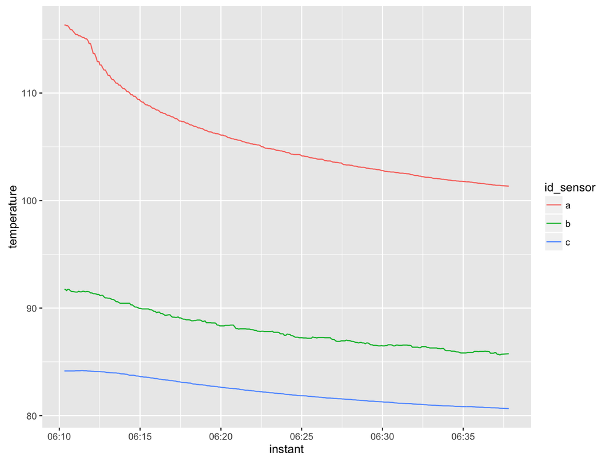

```r
temperature_tall %>%
  ggplot(aes(x = instant, y = temperature, color = id_sensor)) +
  geom_line()
```

# Rearrange a bit more

**`delta_time`** $\Delta t$

change in time since event started, s

**`delta_temperature`**: $\Delta T$

change in temperature since event started, °C

```r
delta <-
  temperature_tall %>%
  arrange(id_sensor, instant) %>%
  group_by(id_sensor) %>%
  mutate(
    delta_time = as.numeric(instant) - as.numeric(instant[[1]]),
    delta_temperature = temperature - temperature[[1]]
  ) %>%
  select(id_sensor, delta_time, delta_temperature)
```

# Let’s have a look

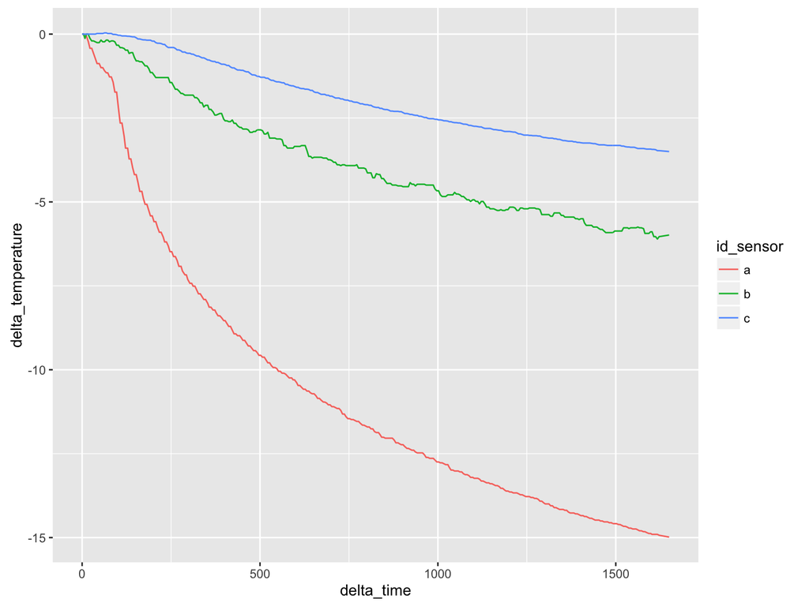

```r
delta %>%
  ggplot(aes(x = delta_time, y = delta_temperature, color = id_sensor)) +
  geom_line()
```

# Curve-fitting

We want to see how three different curve-fits might perform on these three data-sets:

### Newtonian cooling

$$\Delta T = \Delta {T_0} \left[ 1 - \exp \left( { - \frac{{\Delta t}}{{{\tau _0}}}} \right) \right]$$

### Semi-infinite solid

$$\Delta T = \Delta {T_0}\operatorname{erfc} \left( {\sqrt {\frac{{{\tau _0}}}{{\Delta t}}} } \right)$$

### Semi-infinite solid with convection

$$\Delta T = \Delta {T_0}\left[ {\operatorname{erfc} \left( {\sqrt {\frac{{{\tau _0}}}{{\Delta t}}} } \right) - \exp \left( {B{i_0} + \frac{{Bi_0^2}}{4}\frac{{\Delta t}}{{{\tau _0}}}} \right)\operatorname{erfc} \left( {\sqrt {\frac{{{\tau _0}}}{{\Delta t}}} + \frac{{Bi_0^{}}}{2}\sqrt {\frac{{\Delta t}}{{{\tau _0}}}} } \right)} \right]$$

# Some definitions

```r
# reference: http://stackoverflow.com/questions/29067916/r-error-function-erfz
# (see Abramowitz and Stegun 29.2.29)
erf <- function(x) 2 * pnorm(x * sqrt(2)) - 1
erfc <- function(x) 2 * pnorm(x * sqrt(2), lower = FALSE)
```

```r
newton_cooling <- function(x) {
  nls(
    delta_temperature ~ delta_temperature_0*(1 - exp(-delta_time/tau_0)),
    start = list(delta_temperature_0 = -10, tau_0 = 50),
    data = x
  )
}
```

# More math

```r
semi_infinite_simple <- function(x) {
  nls(
    delta_temperature ~ delta_temperature_0*erfc(sqrt(tau_0/delta_time)),
    start = list(delta_temperature_0 = -10, tau_0 = 50),
    data = x
  )
}

semi_infinite_convection <- function(x){
  nls(
    delta_temperature ~
      delta_temperature_0*(
        erfc(sqrt(tau_0/delta_time)) -
        exp(Bi_0 + (Bi_0/2)^2*delta_time/tau_0)*
          erfc(sqrt(tau_0/delta_time) +
        (Bi_0/2)*sqrt(delta_time/tau_0))
      ),
    start = list(delta_temperature_0 = -5, tau_0 = 50, Bi_0 = 1.e6),
    data = x
  )
}
```

# Before we get into purrr

Before doing anything, we want to show that we can do something with one dataset and one model-function:

```r
tmp_data <- delta %>% filter(id_sensor == "a")

tmp_model <- newton_cooling(tmp_data)

summary(tmp_model)
```

```
Formula: delta_temperature ~ delta_temperature_0 * (1 - exp(-delta_time/tau_0))

Parameters:
                     Estimate Std. Error t value Pr(>|t|)
delta_temperature_0 -15.06085    0.05262  -286.2   <2e-16 ***
tau_0               500.01382    4.83673   103.4   <2e-16 ***
---
Signif. codes:  0 '***' 0.001 '**' 0.01 '*' 0.05 '.' 0.1 ' ' 1

Residual standard error: 0.3267 on 325 degrees of freedom

Number of iterations to convergence: 7
Achieved convergence tolerance: 4.136e-06
```

# Look at predictions

```r
tmp_pred <-
  tmp_data %>%
  mutate(modeled = predict(tmp_model, data = .)) %>%
  select(id_sensor, delta_time, measured = delta_temperature, modeled) %>%
  gather("type", "delta_temperature", measured:modeled) %>%
  print()
```

```
Source: local data frame [654 x 4]
Groups: id_sensor [1]

   id_sensor delta_time     type delta_temperature
       (chr)      (dbl)    (chr)             (dbl)
1          a          0 measured             0.000
2          a          4 measured             0.000
3          a          8 measured            -0.060
4          a         12 measured            -0.060
5          a         17 measured            -0.211
6          a         22 measured            -0.423
7          a         27 measured            -0.423
8          a         32 measured            -0.574
9          a         37 measured            -0.726
10         a         42 measured            -0.878
..       ...        ...      ...               ...
```

# A more-useful look

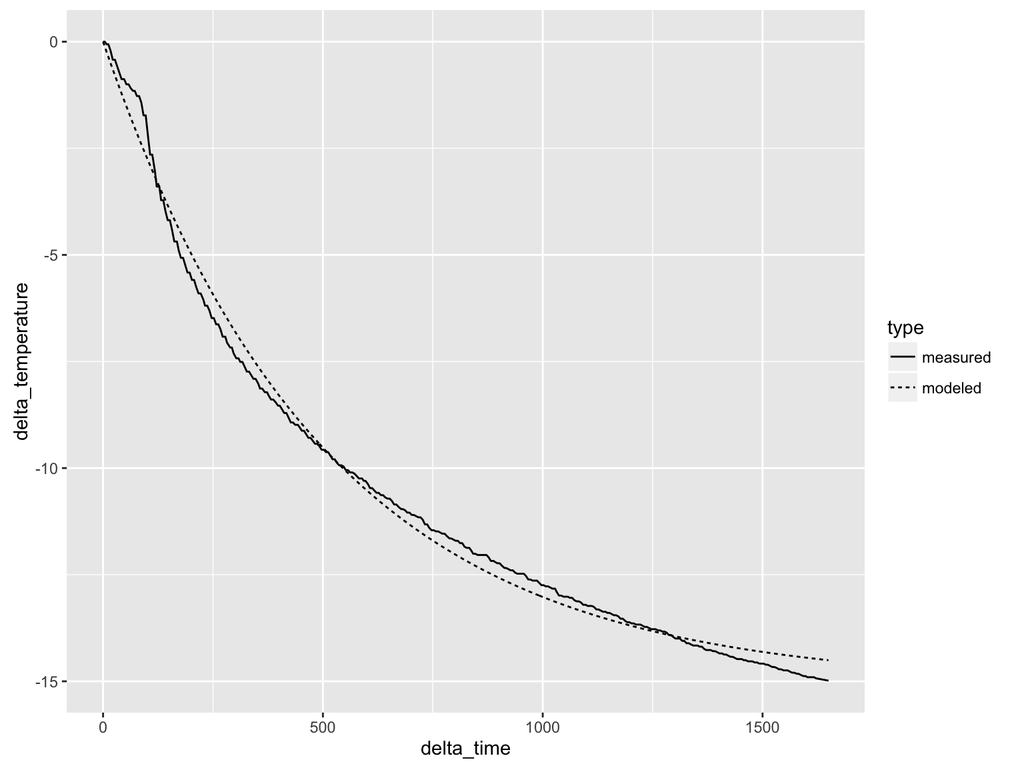

```r
tmp_pred %>%
  ggplot(aes(x = delta_time, y = delta_temperature, linetype = type)) +
  geom_line()
```

# “Regular” data-frame

```r
print(delta)
```

```
Source: local data frame [981 x 3]
Groups: id_sensor [3]

   id_sensor delta_time delta_temperature
       (chr)      (dbl)             (dbl)
1          a          0             0.000
2          a          4             0.000
3          a          8            -0.060
4          a         12            -0.060
5          a         17            -0.211
6          a         22            -0.423
7          a         27            -0.423
8          a         32            -0.574
9          a         37            -0.726
10         a         42            -0.878
..       ...        ...               ...
```

Each column of the dataframe is a vector - in this case, a character vector and two doubles

# How to make a weird data-frame

Here’s where the fun starts - a column of a data-frame can be a list.

- use `tidyr::nest()` to makes a column `data`, which is a list of data-frames
- this seems like a stronger expression of the `dplyr::group_by()` idea

```r
delta_nested <-
  delta %>%
  nest(-id_sensor) %>%
  print()
```

```
Source: local data frame [3 x 2]

  id_sensor             data
      (chr)            (chr)
1         a <tbl_df [327,2]>
2         b <tbl_df [327,2]>
3         c <tbl_df [327,2]>
```

# Map data-frames to the modeling function

- `map()` is like `lapply()`
- `map()` returns a list-column (it keeps the weirdness)

```r
model_nested <-
  delta_nested %>%
  mutate(model = map(data, newton_cooling)) %>%
  print()
```

```
Source: local data frame [3 x 3]

  id_sensor             data    model
      (chr)            (chr)    (chr)
1         a <tbl_df [327,2]> <S3:nls>
2         b <tbl_df [327,2]> <S3:nls>
3         c <tbl_df [327,2]> <S3:nls>
```

# We can use `map2()` to make the predictions

- `map2()` is like `mapply()`
- designed to map two colunms (`model`, `data`) to a function `predict()`

```r
predict_nested <-
  model_nested %>%
  mutate(pred = map2(model, data, predict)) %>%
  print()
```

```
Source: local data frame [3 x 4]

  id_sensor             data    model       pred
      (chr)            (chr)    (chr)      (chr)
1         a <tbl_df [327,2]> <S3:nls> <dbl[327]>
2         b <tbl_df [327,2]> <S3:nls> <dbl[327]>
3         c <tbl_df [327,2]> <S3:nls> <dbl[327]>
```

# We need to get out of the weirdness

- use `unnest()` to get back to a regular data-frame

```r
predict_unnested <-
  predict_nested %>%
  unnest(data, pred) %>%
  print()
```

```
Source: local data frame [981 x 4]

   id_sensor       pred delta_time delta_temperature
       (chr)      (dbl)      (dbl)             (dbl)
1          a  0.0000000          0             0.000
2          a -0.1200028          4             0.000
3          a -0.2390494          8            -0.060
4          a -0.3571475         12            -0.060
5          a -0.5034477         17            -0.211
6          a -0.6482923         22            -0.423
7          a -0.7916957         27            -0.423
8          a -0.9336722         32            -0.574
9          a -1.0742360         37            -0.726
10         a -1.2134013         42            -0.878
..       ...        ...        ...               ...
```

# We can wrangle the predictions

- get into a form that makes it easier to plot

```r
predict_tall <-
  predict_unnested %>%
  rename(modeled = pred, measured = delta_temperature) %>%
  gather("type", "delta_temperature", modeled, measured) %>%
  print()
```

```
Source: local data frame [1,962 x 4]

   id_sensor delta_time    type delta_temperature
       (chr)      (dbl)   (chr)             (dbl)
1          a          0 modeled         0.0000000
2          a          4 modeled        -0.1200028
3          a          8 modeled        -0.2390494
4          a         12 modeled        -0.3571475
5          a         17 modeled        -0.5034477
6          a         22 modeled        -0.6482923
7          a         27 modeled        -0.7916957
8          a         32 modeled        -0.9336722
9          a         37 modeled        -1.0742360
10         a         42 modeled        -1.2134013
..       ...        ...     ...               ...
```

# We can visualize the predictions

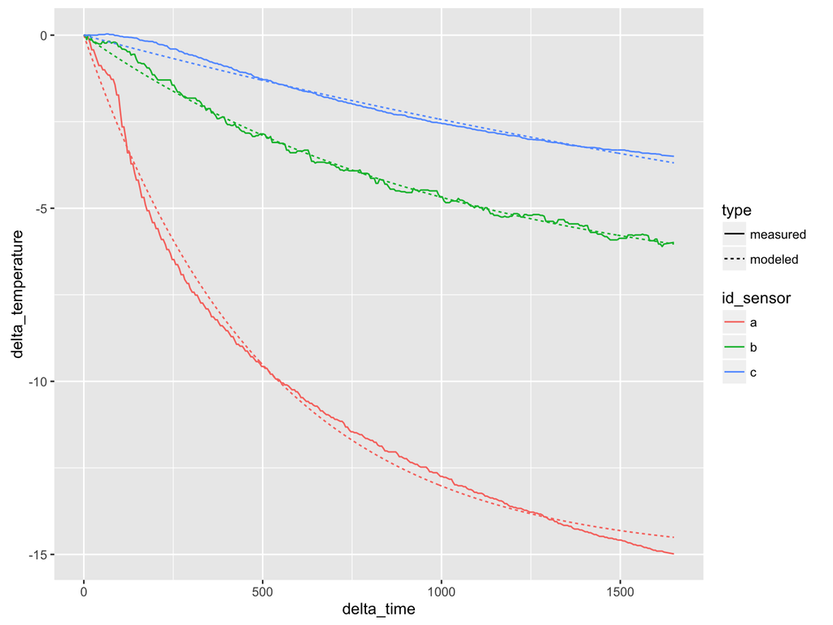

```r
predict_tall %>%
  ggplot(aes(x = delta_time, y = delta_temperature)) +
  geom_line(aes(color = id_sensor, linetype = type))
```

# Now we want to look at a selection of models

Make a list of functions to model:

```r
list_model <-
  list(
    newton_cooling = newton_cooling,
    semi_infinite_simple = semi_infinite_simple,
    semi_infinite_convection = semi_infinite_convection
  )
```

# Step: write a function to define the “inner” loop

```r
fn_model <- function(.model, df){
  # safer to avoid non-standard evaluation
  # df %>% mutate(model = map(data, .model))

  df$model <- map(df$data, possibly(.model, NULL))
  df
}
```

- for a given model-function and a given (weird) data-frame, return a modified version of that data-frame with a column `model`, which is the model-function applied to each element of the data-frame’s `data` column (which is itself a list of data-frames)
- the purrr functions `safely()` and `possibly()` are **very** interesting. I think they could be useful outside of purrr as a friendlier way to do error-handling.

# Step: `map_df()` to define the “outer” loop

```r
model_nested_new <-
  list_model %>%
  map_df(fn_model, delta_nested, .id = "id_model") %>%
  print()
```

```
Source: local data frame [9 x 4]

                  id_model id_sensor             data    model
                     (chr)     (chr)            (chr)    (chr)
1           newton_cooling         a <tbl_df [327,2]> <S3:nls>
2           newton_cooling         b <tbl_df [327,2]> <S3:nls>
3           newton_cooling         c <tbl_df [327,2]> <S3:nls>
4     semi_infinite_simple         a <tbl_df [327,2]> <S3:nls>
5     semi_infinite_simple         b <tbl_df [327,2]> <S3:nls>
6     semi_infinite_simple         c <tbl_df [327,2]> <S3:nls>
7 semi_infinite_convection         a <tbl_df [327,2]>   <NULL>
8 semi_infinite_convection         b <tbl_df [327,2]>   <NULL>
9 semi_infinite_convection         c <tbl_df [327,2]>   <NULL>
```

- for each element of a list of model-functions, run the inner-loop function, and row-bind the results into a data-frame
- we want to discard the rows where the model failed
- we also want to investigate why they failed, but that’s a different talk

# Step: `map()` to identify the null models

```r
model_nested_new <-
  list_model %>%
  map_df(fn_model, delta_nested, .id = "id_model") %>%
  mutate(is_null = map(model, is.null)) %>%
  print()
```

```
Source: local data frame [9 x 5]

                  id_model id_sensor             data    model  is_null
                     (chr)     (chr)            (chr)    (chr)    (chr)
1           newton_cooling         a <tbl_df [327,2]> <S3:nls> <lgl[1]>
2           newton_cooling         b <tbl_df [327,2]> <S3:nls> <lgl[1]>
3           newton_cooling         c <tbl_df [327,2]> <S3:nls> <lgl[1]>
4     semi_infinite_simple         a <tbl_df [327,2]> <S3:nls> <lgl[1]>
5     semi_infinite_simple         b <tbl_df [327,2]> <S3:nls> <lgl[1]>
6     semi_infinite_simple         c <tbl_df [327,2]> <S3:nls> <lgl[1]>
7 semi_infinite_convection         a <tbl_df [327,2]>   <NULL> <lgl[1]>
8 semi_infinite_convection         b <tbl_df [327,2]>   <NULL> <lgl[1]>
9 semi_infinite_convection         c <tbl_df [327,2]>   <NULL> <lgl[1]>
```

- using `map(model, is.null)` returns a list column
- to use `filter()`, we have to escape the weirdness

# Step: `map_lgl()` to identify nulls and get out of the weirdness

```r
model_nested_new <-
  list_model %>%
  map_df(fn_model, delta_nested, .id = "id_model") %>%
  mutate(is_null = map_lgl(model, is.null)) %>%
  print()
```

```
Source: local data frame [9 x 5]

                  id_model id_sensor             data    model is_null
                     (chr)     (chr)            (chr)    (chr)   (lgl)
1           newton_cooling         a <tbl_df [327,2]> <S3:nls>   FALSE
2           newton_cooling         b <tbl_df [327,2]> <S3:nls>   FALSE
3           newton_cooling         c <tbl_df [327,2]> <S3:nls>   FALSE
4     semi_infinite_simple         a <tbl_df [327,2]> <S3:nls>   FALSE
5     semi_infinite_simple         b <tbl_df [327,2]> <S3:nls>   FALSE
6     semi_infinite_simple         c <tbl_df [327,2]> <S3:nls>   FALSE
7 semi_infinite_convection         a <tbl_df [327,2]>   <NULL>    TRUE
8 semi_infinite_convection         b <tbl_df [327,2]>   <NULL>    TRUE
9 semi_infinite_convection         c <tbl_df [327,2]>   <NULL>    TRUE
```

- using `map_lgl(model, is.null)` returns a vector column

# Step: `filter()` and `select()` to clean up

```r
model_nested_new <-
  list_model %>%
  map_df(fn_model, delta_nested, .id = "id_model") %>%
  mutate(is_null = map_lgl(model, is.null)) %>%
  filter(!is_null) %>%
  select(-is_null) %>%
  print()
```

```
Source: local data frame [6 x 4]

              id_model id_sensor             data    model
                 (chr)     (chr)            (chr)    (chr)
1       newton_cooling         a <tbl_df [327,2]> <S3:nls>
2       newton_cooling         b <tbl_df [327,2]> <S3:nls>
3       newton_cooling         c <tbl_df [327,2]> <S3:nls>
4 semi_infinite_simple         a <tbl_df [327,2]> <S3:nls>
5 semi_infinite_simple         b <tbl_df [327,2]> <S3:nls>
6 semi_infinite_simple         c <tbl_df [327,2]> <S3:nls>
```

# Let’s get predictions

```r
predict_nested <-
  model_nested_new %>%
  mutate(pred = map2(model, data, predict)) %>%
  print()
```

```
Source: local data frame [6 x 5]

              id_model id_sensor             data    model       pred
                 (chr)     (chr)            (chr)    (chr)      (chr)
1       newton_cooling         a <tbl_df [327,2]> <S3:nls> <dbl[327]>
2       newton_cooling         b <tbl_df [327,2]> <S3:nls> <dbl[327]>
3       newton_cooling         c <tbl_df [327,2]> <S3:nls> <dbl[327]>
4 semi_infinite_simple         a <tbl_df [327,2]> <S3:nls> <dbl[327]>
5 semi_infinite_simple         b <tbl_df [327,2]> <S3:nls> <dbl[327]>
6 semi_infinite_simple         c <tbl_df [327,2]> <S3:nls> <dbl[327]>
```

# `unnest()`, make it tall

```r
predict_tall <-
  predict_nested %>%
  unnest(data, pred) %>%
  rename(modeled = pred, measured = delta_temperature) %>%
  gather("type", "delta_temperature", modeled, measured) %>%
  print()
```

```
Source: local data frame [3,924 x 5]

         id_model id_sensor delta_time    type delta_temperature
            (chr)     (chr)      (dbl)   (chr)             (dbl)
1  newton_cooling         a          0 modeled         0.0000000
2  newton_cooling         a          4 modeled        -0.1200028
3  newton_cooling         a          8 modeled        -0.2390494
4  newton_cooling         a         12 modeled        -0.3571475
5  newton_cooling         a         17 modeled        -0.5034477
6  newton_cooling         a         22 modeled        -0.6482923
7  newton_cooling         a         27 modeled        -0.7916957
8  newton_cooling         a         32 modeled        -0.9336722
9  newton_cooling         a         37 modeled        -1.0742360
10 newton_cooling         a         42 modeled        -1.2134013
..            ...       ...        ...     ...               ...
```

# We can visualize the predictions

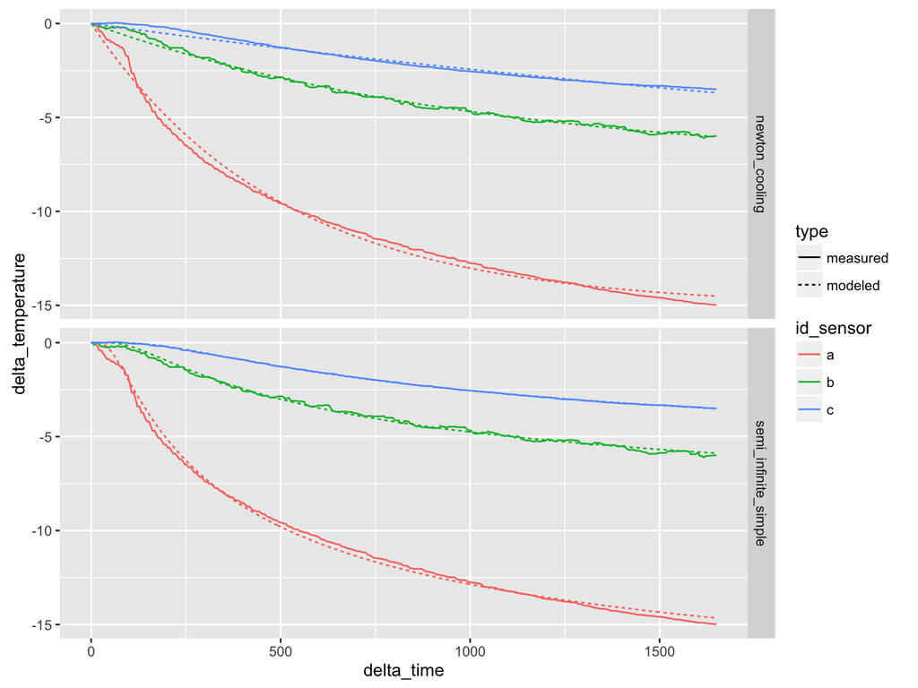

```r
predict_tall %>%
  ggplot(aes(x = delta_time, y = delta_temperature)) +
  geom_line(aes(color = id_sensor, linetype = type)) +
  facet_grid(id_model ~ .)
```

# Let’s get the residuals

```r
resid <-
  model_nested_new %>%
  mutate(resid = map(model, resid)) %>%
  unnest(data, resid) %>%
  print()
```

```
Source: local data frame [1,962 x 5]

         id_model id_sensor     resid delta_time delta_temperature
            (chr)     (chr)     (dbl)      (dbl)             (dbl)
1  newton_cooling         a 0.0000000          0             0.000
2  newton_cooling         a 0.1200028          4             0.000
3  newton_cooling         a 0.1790494          8            -0.060
4  newton_cooling         a 0.2971475         12            -0.060
5  newton_cooling         a 0.2924477         17            -0.211
6  newton_cooling         a 0.2252923         22            -0.423
7  newton_cooling         a 0.3686957         27            -0.423
8  newton_cooling         a 0.3596722         32            -0.574
9  newton_cooling         a 0.3482360         37            -0.726
10 newton_cooling         a 0.3354013         42            -0.878
..            ...       ...       ...        ...               ...
```

# And visualize them

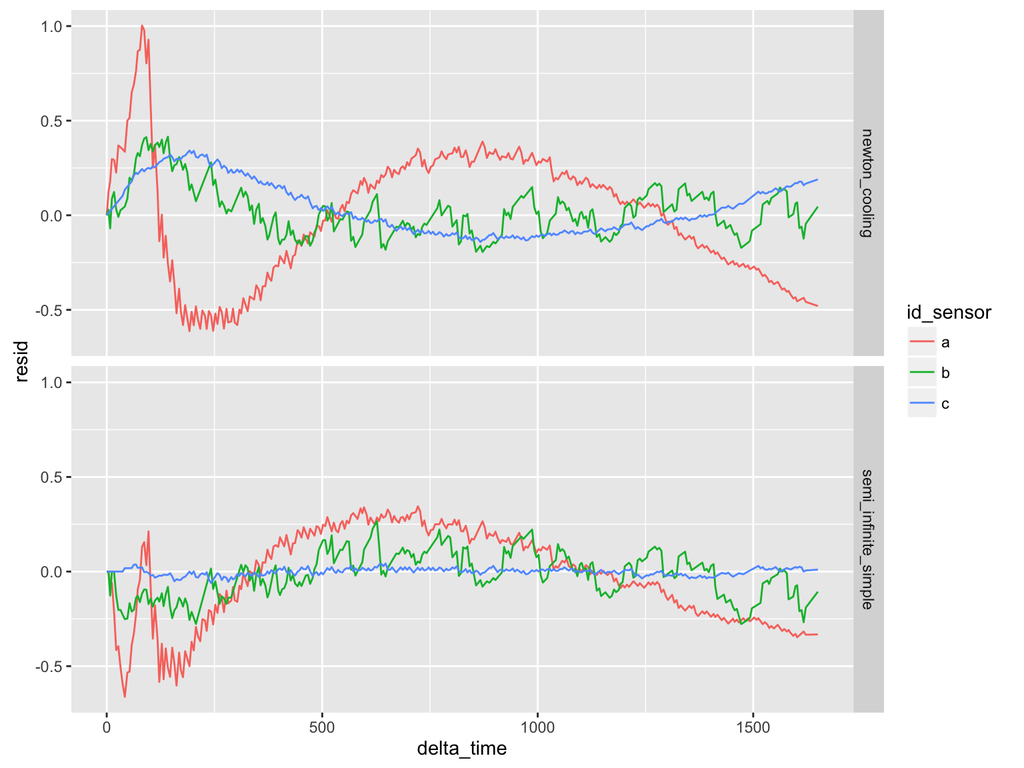

```r
resid %>%
  ggplot(aes(x = delta_time, y = resid)) +
  geom_line(aes(color = id_sensor)) +
  facet_grid(id_model ~ .)
```

# Using broom package to look at model-statistics

The `tidy()` function extracts statistics from a model

```r
model_parameters <-
  model_nested_new %>%
  select(id_model, id_sensor, model) %>%
  mutate(tidy = map(model, tidy)) %>%
  select(-model) %>%
  unnest() %>%
  print()
```

```
Source: local data frame [12 x 7]

               id_model id_sensor                term    estimate
                  (chr)     (chr)               (chr)       (dbl)
1        newton_cooling         a delta_temperature_0  -15.060846
2        newton_cooling         a               tau_0  500.013816
3        newton_cooling         b delta_temperature_0   -7.586358
4        newton_cooling         b               tau_0 1040.998492
5        newton_cooling         c delta_temperature_0   -9.868669
6        newton_cooling         c               tau_0 3525.408736
7  semi_infinite_simple         a delta_temperature_0  -21.509591
8  semi_infinite_simple         a               tau_0  139.222798
9  semi_infinite_simple         b delta_temperature_0  -10.582386
10 semi_infinite_simple         b               tau_0  286.599175
11 semi_infinite_simple         c delta_temperature_0   -8.042915
12 semi_infinite_simple         c               tau_0  499.887374
Variables not shown: std.error (dbl), statistic (dbl), p.value (dbl)
```

# Get a sense of the coefficients

```r
model_summary <-
  model_parameters %>%
  select(id_model, id_sensor, term, estimate) %>%
  spread(key = "term", value = "estimate") %>%
  print()
```

```
Source: local data frame [6 x 4]

              id_model id_sensor delta_temperature_0     tau_0
                 (chr)     (chr)               (dbl)     (dbl)
1       newton_cooling         a          -15.060846  500.0138
2       newton_cooling         b           -7.586358 1040.9985
3       newton_cooling         c           -9.868669 3525.4087
4 semi_infinite_simple         a          -21.509591  139.2228
5 semi_infinite_simple         b          -10.582386  286.5992
6 semi_infinite_simple         c           -8.042915  499.8874
```

# Summary

- this is just a smalll part of purrr
- there seem to be parallels between `tidyr::nest()/purrr::map()` and `dplyr::group_by()/dplyr::do()`
  - to my mind, the purrr framework is more understandable
  - update tweet from [Hadley](https://twitter.com/hadleywickham/status/719542847045636096)

References from Hadley:

- [purrr 0.1.0 announcement](http://blog.rstudio.org/2015/09/29/purrr-0-1-0/)
- [purrr 0.2.0 announcement](http://blog.rstudio.org/2016/01/06/purrr-0-2-0/)
- [chapter from Garrett Grolemund and Hadley’s forthcoming book](http://r4ds.had.co.nz/iteration.html)